# How to use GetTDData

Marcelo Perlin

2023-01-03

Information regarding prices and yields of bonds issued by the Brazilian government can be downloaded manually as excel files from the [Tesouro Direto website](https://www.tesourodireto.com.br/). However, it can be painful to aggregate all of this data into something useful as the files don’t have an uniform format and are all divided by year and asset code.

Package GetTDData makes the process of importing data from Tesouro direto much easier. All you need is the name of fixed income assets (LFT, LTN, NTN-C, NTN-B, NTN-B Principal, NTN-F).

## How to use GetTDData

Suppose you need financial data (prices and yields) for a bond of type LTN with a maturity (end of contract) at 2023-01-01. This bullet bond is the most basic debt contract the Brazilian government issues. It does not pay any value (coupon) during its lifetime and will pay 1000 R$ at maturity.

In order to get the data, all you need to do is to run the following code in R:

```r
library(GetTDData)

asset.codes <- 'LTN'   # Identifier of assets
cache_folder <- paste0(tempdir(), '/TD_cache')

my.flag <- download.TD.data(asset.codes = asset.codes,
                            dl.folder = cache_folder)
my.df <- read.TD.files(dl.folder = cache_folder)
```

[output not shown]

[output cut: 83 more lines]

[output not shown]

Let’s plot the prices to check if the code worked:

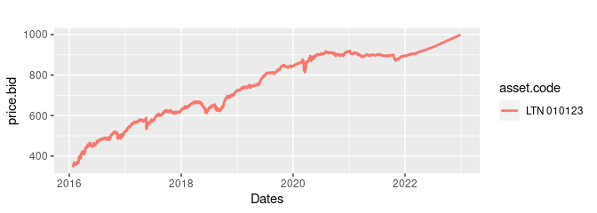

```r
library(ggplot2)
library(dplyr)
# filter  LTN
my_asset_code <- "LTN 010123"
first_date <- as.Date("2015-01-01")

my.df <- my.df %>%
  filter(ref.date >= first_date)

LTN <- my.df %>%
  filter(asset.code  ==  my_asset_code,
         ref.date >= first_date)

p <- ggplot(data = LTN,
            aes(x = as.Date(ref.date),
                y = price.bid,
                color = asset.code)) +
  geom_line(size = 1) + scale_x_date() + labs(title = '', x = 'Dates')
print(p)
```

As expected, the prices from this bond will converge to its face value, 1000 R$, at the maturity date. We can also look at its time-varying annual yield:

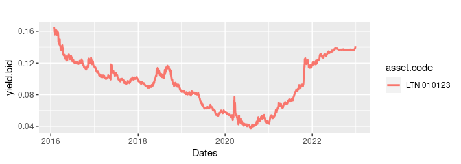

```r
p <- ggplot(data = LTN,
            aes(x = as.Date(ref.date),
                y = yield.bid,
                color = asset.code)) +
  geom_line(size = 1) +
  scale_x_date() +
  labs(title = '',
       x = 'Dates')

print(p)
```

By default, `GetTDData` downloads all available data from the website. Suppose we wanted to look at the prices of all available maturities for bonds of type LTN. Since the data is already downloaded, all we need to do is to plot the prices and yields of the different debt contracts:

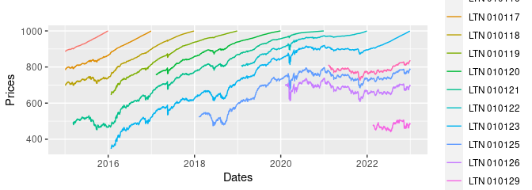

```r
# plot data (prices)
p <- ggplot(data = my.df,
            aes(x = as.Date(ref.date), y = price.bid, color = asset.code)) +
  geom_line() +
  scale_x_date() +
  labs(title = '', x = 'Dates', y = 'Prices' )

print(p)
```

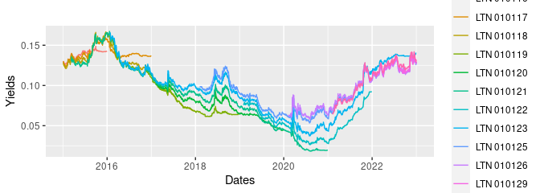

```r
# plot data (yields)
p <- ggplot(data = my.df,
            aes(x = as.Date(ref.date), y = yield.bid, color = asset.code)) +
  geom_line() +
  scale_x_date() +
  labs(title = '', x = 'Dates', y = 'Yields' )

print(p)
```